# Spline regression and train/test strategies for the GC bias

Ido Shalom, Daniel Rodan, Sagi Levin

25 June, 2024

### Libraries used

```r
# Load libraries
library("ggplot2")
library("data.table")
library("tictoc")
library("manipulate")
library(tidyverse)
library(fitdistrplus)
library(dplyr)
library(ggthemes)
library(scales)
library(gridExtra)
library(splines)
library(knitr)
```

### Paths and Data

```r
# Load the data for GC count
load(file = 'data/chr1_str_30M_50M.rda')

# Load the data for reads per cell
reads_file = 'data/raw/TCGA-13-0723-01A_lib1_all_chr1.forward'
```

```r
# Split letters
my_data = strsplit(chr1_str_30M_50M, '')[[1]][-1]

# Count bases in total
table(my_data)
```

```
## my_data
##       A       C       G       T
## 5487636 4541430 4517653 5453281
```

```r
# Load chromosome 1 reads
chr1_reads = fread(reads_file)

# Adding relevant columns names
colnames(chr1_reads) = c("Chrom","Loc","FragLen")

# Display summary
summary(chr1_reads)
```

```
##      Chrom        Loc               FragLen
##  Min.   :1   Min.   :       28   Min.   :-244390263
##  1st Qu.:1   1st Qu.: 43839514   1st Qu.:       144
##  Median :1   Median :108417844   Median :       155
##  Mean   :1   Mean   :116496437   Mean   :       846
##  3rd Qu.:1   3rd Qu.:186713491   3rd Qu.:       165
##  Max.   :1   Max.   :247199180   Max.   : 244920509
```

## Introduction

In this week’s task, we will try to fit spline regressions for the CG content vs. reads coverage and also examine the effects of different division strategies into train and test areas.

## Setup

In preparation for this week’s task, we will first need to generate several items from our data:

- A function that counts the number of C+G bases per 5k cell.
- A function that calculates the number of reads per 5k cell.
- A filtered scatter plot of CG Content vs. Reads Coverage.

**Notes:**

- We chose a 5k cell size after trying different sizes, and this size best captures the decline in reads after the 0.6 CG content mark.
- We fitted the length and location of our segment from chromosome 1 for Lab 1 (30M - 50M) to be the exact part used in the reads file.

*The CG Count per cell function:*

```r
# Define the function to count C+G bases per cell
sum_CG_bases_in_cells <- function(genome, cell_size) {
  genome_length <- nchar(genome)

  # Initialize a vector to store the CG counts per cell
  CG_counts_per_cell <- numeric(ceiling(genome_length / cell_size))

  # Iterate over the genome by cell_size
  for (i in seq(1, genome_length, by = cell_size)) {
    end <- min(i + cell_size - 1, genome_length)
    cell <- substring(genome, i, end)

    # Count C and G bases in the cell
    CG_count <- sum(charToRaw(cell) == charToRaw("C")) + sum(charToRaw(cell) == charToRaw("G"))

    # Store the CG count in the vector
    CG_counts_per_cell[(i - 1) %/% cell_size + 1] <- CG_count
  }

  return(CG_counts_per_cell)
}


# Calculate CG counts per cell of size 5,000
CG_counts_5k <- sum_CG_bases_in_cells(chr1_str_30M_50M, 5000)
```

*The reads per cell function:*

```r
# Define the start and end base positions
start_base <- 30000000
end_base <- 50000000
cell_size <- 5000

# Filter reads to the range of interest
reads_filtered <- chr1_reads[Loc >= start_base & Loc <= end_base]

# Function to calculate the number of reads per cell
calculateReadsPerCell <- function(reads, cell_size, start_base, end_base) {
  num_cells <- ceiling((end_base - start_base + 1) / cell_size)
  reads_per_cell <- integer(num_cells)

  for (i in seq_len(num_cells)) {
    cell_start <- start_base + (i - 1) * cell_size
    cell_end <- min(cell_start + cell_size - 1, end_base)
    reads_per_cell[i] <- sum(reads$Loc >= cell_start & reads$Loc <= cell_end)
  }

  return(reads_per_cell)
}

# Calculate the coverage per cell
reads_cell_5k <- calculateReadsPerCell(reads_filtered, cell_size, start_base, end_base)
```

*Plot of CG content vs read coverage with relevant filters:*

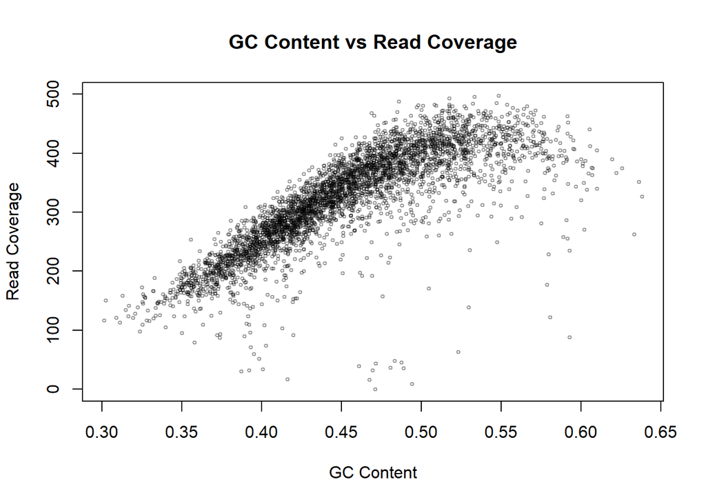

```r
# Normalize CG counts if necessary
if (any(CG_counts_5k > 1)) {
  CG_counts_5k <- CG_counts_5k / 5000
}


# Filter the data
filtered_index <- (reads_cell_5k <= 500) & (CG_counts_5k >= 0.29) & (CG_counts_5k<= 0.64)
GC_content_filtered <- CG_counts_5k[filtered_index]
reads_filtered <- reads_cell_5k[filtered_index]

# Plot the data with explicit x-axis limits
plot(GC_content_filtered, reads_filtered, col = rgb(0, 0, 0, 0.4), ylim = c(0, 500), cex = 0.5,
     xlab = "GC Content", ylab = "Read Coverage", main = "GC Content vs Read Coverage")
```

## Part A: Data Splitting Strategies

### Random 20 Equal Parts:

```r
# Define the knots
knots <- c(0.36, 0.43, 0.50, 0.57)

set.seed(127)  # For reproducibility
num_parts <- 20
part_length <- length(GC_content_filtered) %/% num_parts

# Generate indices for the parts
part_indices <- sample(rep(1:num_parts, each = part_length, length.out = length(GC_content_filtered)))

# Randomly assign 14 parts to the train set
train_parts <- sample(num_parts, 14)
train_index_1 <- part_indices %in% train_parts
test_index_1 <- !train_index_1

# Train and test sets
train_set_1 <- data.frame(GC_content = GC_content_filtered[train_index_1], Reads = reads_filtered[train_index_1])
test_set_1 <- data.frame(GC_content = GC_content_filtered[test_index_1], Reads = reads_filtered[test_index_1])
```

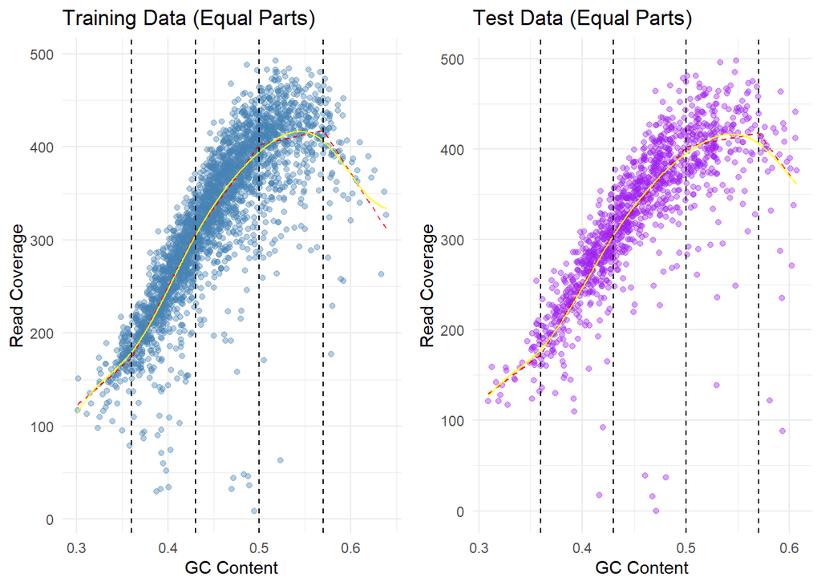

```r
# Fit the linear spline regression model to the training data
linear_spline_model_1 <- lm(Reads ~ bs(GC_content, knots = knots, degree = 1), data = train_set_1)

# Fit the cubic spline regression model to the training data
cubic_spline_model_1 <- lm(Reads ~ bs(GC_content, knots = knots), data = train_set_1)

# Predict on training data for both models
linear_train_predictions_1 <- predict(linear_spline_model_1, newdata = train_set_1)
cubic_train_predictions_1 <- predict(cubic_spline_model_1, newdata = train_set_1)

# Predict on test data for both models
linear_test_predictions_1 <- predict(linear_spline_model_1, newdata = test_set_1)
cubic_test_predictions_1 <- predict(cubic_spline_model_1, newdata = test_set_1)

# Create the training plot
train_plot_1 <- ggplot(train_set_1, aes(x = GC_content, y = Reads)) +
  geom_point(alpha = 0.4, color = "steelblue") +
  geom_line(aes(y = linear_train_predictions_1), color = "red", linetype = "dashed") +
  geom_line(aes(y = cubic_train_predictions_1), color = "yellow") +
  geom_vline(xintercept = knots, linetype = "dashed", color = "black", size = 0.4) +
  labs(title = "Training Data (Equal Parts)",
       x = "GC Content", y = "Read Coverage") +
  theme_minimal()

# Create the test plot
test_plot_1 <- ggplot(test_set_1, aes(x = GC_content, y = Reads)) +
  geom_point(alpha = 0.4, color = "purple") +
  geom_line(aes(y = linear_test_predictions_1), color = "red", linetype = "dashed") +
  geom_line(aes(y = cubic_test_predictions_1), color = "yellow") +
  geom_vline(xintercept = knots, linetype = "dashed", color = "black", size = 0.4) +
  labs(title = "Test Data (Equal Parts)",
       x = "GC Content", y = "Read Coverage") +
  theme_minimal()

# Arrange the plots side by side
grid.arrange(train_plot_1, test_plot_1, ncol = 2)
```

```r
# Calculate R-squared for linear spline on training data
linear_train_r2_1 <- summary(linear_spline_model_1)$r.squared

# Calculate R-squared for cubic spline on training data
cubic_train_r2_1 <- summary(cubic_spline_model_1)$r.squared

# Calculate R-squared for linear spline on test data
linear_test_r2_1 <- 1 - sum((test_set_1$Reads - linear_test_predictions_1)^2) / sum((test_set_1$Reads - mean(test_set_1$Reads))^2)

# Calculate R-squared for cubic spline on test data
cubic_test_r2_1 <- 1 - sum((test_set_1$Reads - cubic_test_predictions_1)^2) / sum((test_set_1$Reads - mean(test_set_1$Reads))^2)

# Fit simple linear regression model to the training data for equal parts (_1)
linear_model_1 <- lm(Reads ~ GC_content, data = train_set_1)
linear_train_predictions_1 <- predict(linear_model_1, newdata = train_set_1)
linear_test_predictions_1 <- predict(linear_model_1, newdata = test_set_1)

# Calculate R-squared for simple linear regression on training data
linear_train_r2_simple_1 <- summary(linear_model_1)$r.squared

# Calculate R-squared for simple linear regression on test data
linear_test_r2_simple_1 <- 1 - sum((test_set_1$Reads - linear_test_predictions_1)^2) / sum((test_set_1$Reads - mean(test_set_1$Reads))^2)
```

### Completely Random Split:

```r
# Set seed for reproducibility
set.seed(245)

# Randomly sample 70% of the cells for training and 30% for testing
random_sample_2 <- sample(length(GC_content_filtered), size = 0.7 * length(GC_content_filtered))

train_index_2 <- rep(FALSE, length(GC_content_filtered))
train_index_2[random_sample_2] <- TRUE
test_index_2 <- !train_index_2

# Train and test sets
train_set_2 <- data.frame(GC_content = GC_content_filtered[train_index_2], Reads = reads_filtered[train_index_2])
test_set_2 <- data.frame(GC_content = GC_content_filtered[test_index_2], Reads = reads_filtered[test_index_2])
```

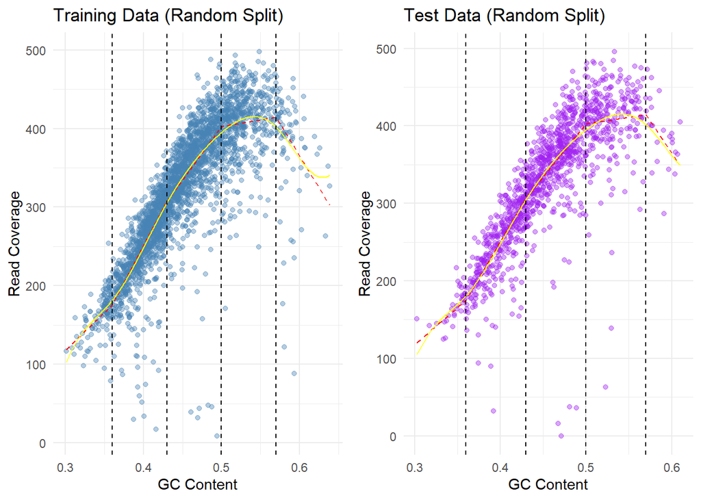

```r
# Fit the linear spline regression model to the training data
linear_spline_model_2 <- lm(Reads ~ bs(GC_content, knots = knots, degree = 1), data = train_set_2)

# Fit the cubic spline regression model to the training data
cubic_spline_model_2 <- lm(Reads ~ bs(GC_content, knots = knots), data = train_set_2)

# Predict on training data for both models
linear_train_predictions_2 <- predict(linear_spline_model_2, newdata = train_set_2)
cubic_train_predictions_2 <- predict(cubic_spline_model_2, newdata = train_set_2)

# Predict on test data for both models
linear_test_predictions_2 <- predict(linear_spline_model_2, newdata = test_set_2)
cubic_test_predictions_2 <- predict(cubic_spline_model_2, newdata = test_set_2)

# Create the training plot
train_plot_2 <- ggplot(train_set_2, aes(x = GC_content, y = Reads)) +
  geom_point(alpha = 0.4, color = "steelblue") +
  geom_line(aes(y = linear_train_predictions_2), color = "red", linetype = "dashed") +
  geom_line(aes(y = cubic_train_predictions_2), color = "yellow") +
  geom_vline(xintercept = knots, linetype = "dashed", color = "black", size = 0.4) +
  labs(title = "Training Data (Random Split)",
       x = "GC Content", y = "Read Coverage") +
  theme_minimal()

# Create the test plot
test_plot_2 <- ggplot(test_set_2, aes(x = GC_content, y = Reads)) +
  geom_point(alpha = 0.4, color = "purple") +
  geom_line(aes(y = linear_test_predictions_2), color = "red", linetype = "dashed") +
  geom_line(aes(y = cubic_test_predictions_2), color = "yellow") +
  geom_vline(xintercept = knots, linetype = "dashed", color = "black", size = 0.4) +
  labs(title = "Test Data (Random Split)",
       x = "GC Content", y = "Read Coverage") +
  theme_minimal()

# Arrange the plots side by side
grid.arrange(train_plot_2, test_plot_2, ncol = 2)
```

```r
# Calculate R-squared for linear spline on training data
linear_train_r2_2 <- summary(linear_spline_model_2)$r.squared

# Calculate R-squared for cubic spline on training data
cubic_train_r2_2 <- summary(cubic_spline_model_2)$r.squared

# Calculate R-squared for linear spline on test data
linear_test_r2_2 <- 1 - sum((test_set_2$Reads - linear_test_predictions_2)^2) / sum((test_set_2$Reads - mean(test_set_2$Reads))^2)

# Calculate R-squared for cubic spline on test data
cubic_test_r2_2 <- 1 - sum((test_set_2$Reads - cubic_test_predictions_2)^2) / sum((test_set_2$Reads - mean(test_set_2$Reads))^2)

# Fit simple linear regression model to the training data for random split (_2)
linear_model_2 <- lm(Reads ~ GC_content, data = train_set_2)
linear_train_predictions_2 <- predict(linear_model_2, newdata = train_set_2)
linear_test_predictions_2 <- predict(linear_model_2, newdata = test_set_2)

# Calculate R-squared for simple linear regression on training data
linear_train_r2_simple_2 <- summary(linear_model_2)$r.squared

# Calculate R-squared for simple linear regression on test data
linear_test_r2_simple_2 <- 1 - sum((test_set_2$Reads - linear_test_predictions_2)^2) / sum((test_set_2$Reads - mean(test_set_2$Reads))^2)
```

### Ordered Split:

```r
# Set seed for reproducibility
set.seed(345)

# Completely ordered distribution
train_index_3 <- 1:floor(0.7 * length(GC_content_filtered))
test_index_3 <- (floor(0.7 * length(GC_content_filtered)) + 1):length(GC_content_filtered)

# Train and test sets
train_set_3 <- data.frame(GC_content = GC_content_filtered[train_index_3], Reads = reads_filtered[train_index_3])
test_set_3 <- data.frame(GC_content = GC_content_filtered[test_index_3], Reads = reads_filtered[test_index_3])
```

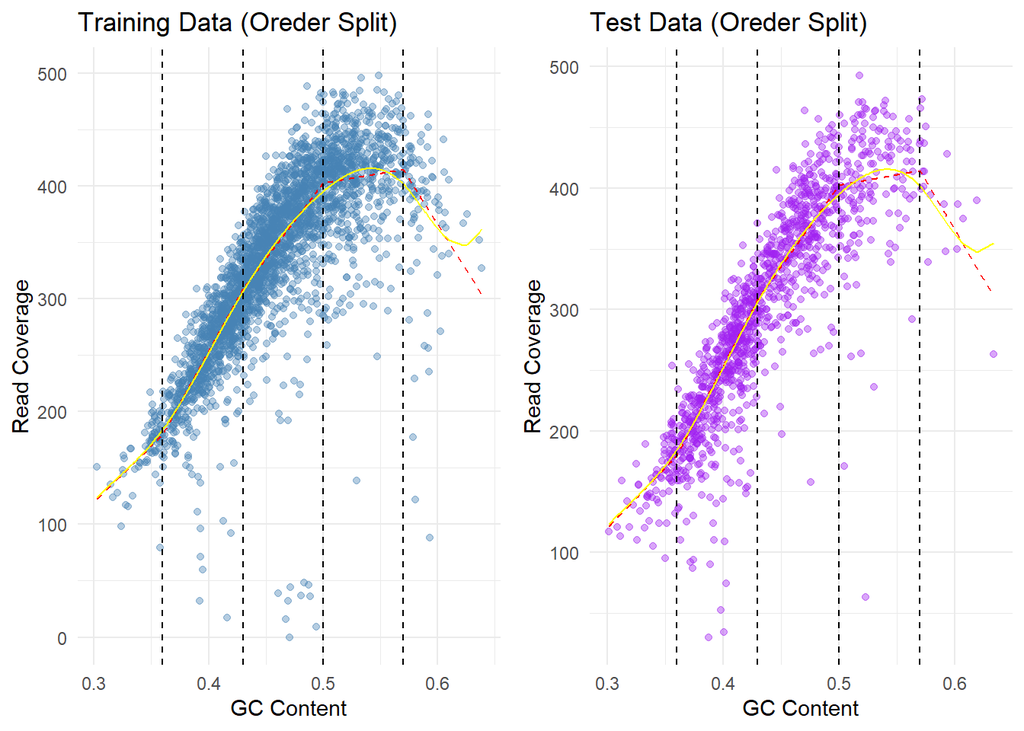

```r
# Fit the linear spline regression model to the training data
linear_spline_model_3 <- lm(Reads ~ bs(GC_content, knots = knots, degree = 1), data = train_set_3)

# Fit the cubic spline regression model to the training data
cubic_spline_model_3 <- lm(Reads ~ bs(GC_content, knots = knots), data = train_set_3)

# Predict on training data for both models
linear_train_predictions_3 <- predict(linear_spline_model_3, newdata = train_set_3)
cubic_train_predictions_3 <- predict(cubic_spline_model_3, newdata = train_set_3)

# Predict on test data for both models
linear_test_predictions_3 <- predict(linear_spline_model_3, newdata = test_set_3)
cubic_test_predictions_3 <- predict(cubic_spline_model_3, newdata = test_set_3)

# Create the training plot
train_plot_3 <- ggplot(train_set_3, aes(x = GC_content, y = Reads)) +
  geom_point(alpha = 0.4, color = "steelblue") +
  geom_line(aes(y = linear_train_predictions_3), color = "red", linetype = "dashed") +
  geom_line(aes(y = cubic_train_predictions_3), color = "yellow") +
  geom_vline(xintercept = knots, linetype = "dashed", color = "black", size = 0.4) +
  labs(title = "Training Data (Oreder Split)",
       x = "GC Content", y = "Read Coverage") +
  theme_minimal()

# Create the test plot
test_plot_3 <- ggplot(test_set_3, aes(x = GC_content, y = Reads)) +
  geom_point(alpha = 0.4, color = "purple") +
  geom_line(aes(y = linear_test_predictions_3), color = "red", linetype = "dashed") +
  geom_line(aes(y = cubic_test_predictions_3), color = "yellow") +
  geom_vline(xintercept = knots, linetype = "dashed", color = "black", size = 0.4) +
  labs(title = "Test Data (Oreder Split)",
       x = "GC Content", y = "Read Coverage") +
  theme_minimal()

# Arrange the plots side by side
grid.arrange(train_plot_3, test_plot_3, ncol = 2)
```

```r
# Calculate R-squared for linear spline on training data
linear_train_r2_3 <- summary(linear_spline_model_3)$r.squared

# Calculate R-squared for cubic spline on training data
cubic_train_r2_3 <- summary(cubic_spline_model_3)$r.squared

# Calculate R-squared for linear spline on test data
linear_test_r2_3 <- 1 - sum((test_set_3$Reads - linear_test_predictions_3)^2) / sum((test_set_3$Reads - mean(test_set_3$Reads))^2)

# Calculate R-squared for cubic spline on test data
cubic_test_r2_3 <- 1 - sum((test_set_3$Reads - cubic_test_predictions_3)^2) / sum((test_set_3$Reads - mean(test_set_3$Reads))^2)

# Fit simple linear regression model to the training data for ordered split (_3)
linear_model_3 <- lm(Reads ~ GC_content, data = train_set_3)
linear_train_predictions_3 <- predict(linear_model_3, newdata = train_set_3)
linear_test_predictions_3 <- predict(linear_model_3, newdata = test_set_3)

# Calculate R-squared for simple linear regression on training data
linear_train_r2_simple_3 <- summary(linear_model_3)$r.squared

# Calculate R-squared for simple linear regression on test data
linear_test_r2_simple_3 <- 1 - sum((test_set_3$Reads - linear_test_predictions_3)^2) / sum((test_set_3$Reads - mean(test_set_3$Reads))^2)
```

**Results Explanations:**

When looking at the graphs in general, it is not possible to see drastic changes between the three divisions. For all three divisions, the linear spline performs very well in matching the cubic spline We chose to do a Quantitative measure of $R^2$ as a way to see the general fit of all models.

### Quantitative measure $R^2$ :

```r
# Create a data frame to hold all R-squared values
r2_table <- data.frame(
  Metric = c("Linear_Train_R2", "Linear_Test_R2",
             "Linear_Spline_Train_R2", "Linear_Spline_Test_R2",
             "Cubic_Spline_Train_R2", "Cubic_Spline_Test_R2"),
  `Equal Part (1)` = round(c(linear_train_r2_simple_1, linear_test_r2_simple_1,
                             linear_train_r2_1, linear_test_r2_1,
                             cubic_train_r2_1, cubic_test_r2_1), 3),
  `Random Split (2)` = round(c(linear_train_r2_simple_2, linear_test_r2_simple_2,
                               linear_train_r2_2, linear_test_r2_2,
                               cubic_train_r2_2, cubic_test_r2_2), 3),
  `Order Split (3)` = round(c(linear_train_r2_simple_3, linear_test_r2_simple_3,
                        linear_train_r2_3, linear_test_r2_3,
                        cubic_train_r2_3, cubic_test_r2_3), 3)
)

# Print the table
kable(r2_table, caption = "R-squared values for different models")
```

R-squared values for different models

| Metric | Equal.Part..1. | Random.Split..2. | Order.Split..3. |
| --- | --- | --- | --- |
| Linear_Train_R2 | 0.676 | 0.664 | 0.609 |
| Linear_Test_R2 | 0.618 | 0.650 | 0.709 |
| Linear_Spline_Train_R2 | 0.761 | 0.757 | 0.708 |
| Linear_Spline_Test_R2 | 0.713 | 0.724 | 0.795 |
| Cubic_Spline_Train_R2 | 0.763 | 0.759 | 0.709 |
| Cubic_Spline_Test_R2 | 0.714 | 0.724 | 0.796 |

## Part B: Model Performance Comparison

### Training Data Performance:

- As for normal linear regression, there is almost no difference between the “Equal Part (1)” model and the “Random Split (2)” model, but both are superior to the “Order Split (3)” model.We seem to have found this a bit confusing. In the “Order Split (3)” model, we would expect a high $R^2$ because the parts that are not supposed to be linear are located in high CG areas, so they should be associated with the test and not harm the training.We believe that the reason for the result stems from the large influence of unfiltered extreme values in specific locations that pull the regression line one way or the other. For example, there is a large grouping of cells in the third knot of cells under 50 reeds.
- Regarding both the linear spline and the cubic spline, it seems that the regression is much more accurate for all three divisions, although the “Equal Part (1)” model and the “Random Split (2)” model are still better than the “Order Split (3)” model for the same reasons mentioned above.

### Test Data Performance:

- When examining the training data, the problems of the simple linear model are evident again, especially regarding the “Order Split (3)” model. A possible reason for this is the effect of a change in trends expected at high CG values, plus the sparseness of the data in this region, resulting in a smaller variance and creating a “false” $R^2$ index spike, in a sense.
- It seems that here too, the linear and cubic splines remain quite similar in terms of prediction and perform better compared to the linear test. The false effect of the $R^2$ for the “Order Split (3)” model is still present.

### Possible Reasons for Differences:

As we mentioned above, the difference that really stands out is between the “Order Split (3)” model to the “Equal Part (1)” model & “Random Split (2)” model. The main reason for this is the lack of randomness in model 3, which can affect the difficulty of the model training due to the lack of data in the high GC content region, and also, the bias in the magnitude of the variance in the high GC content region causes a “false” increase $R^2$ in the “Order Split (3)” model .

## Part C: Best Generalization Model

To determine which division strategy best generalizes coverage data on other chromosomes, we need to see how well each method captures the patterns in the data without overfitting.

- The “Equal Part (1)” model reduces overfitting but might miss global trends if the parts aren’t representative of the whole chromosome.
- The “Random Split (2)” model mixing different regions and capturing overall variability. While randomness might make some regions underrepresented, this method balances the training set and reduces bias.
- The “Order Split (3)” model tends to overfit to specific trends in the beginning of the chromosome, missing patterns in the latter part.

Given these points,we think that the “Random Split (2)” model is the best choice for generalization. it captures general trends effectively, as shown by the R-squared values for the test data, making it the preferred method for generalizing to other chromosomes.

## Part D: Residual Analysis

```r
# Calculate residuals for the training data
train_residuals_2 <- train_set_2$Reads - linear_train_predictions_2

# Calculate residuals for the test data
test_residuals_2 <- test_set_2$Reads - linear_test_predictions_2

# Combine residuals and GC content for plotting
train_set_2$residuals <- train_residuals_2
test_set_2$residuals <- test_residuals_2

train_set_2$predicted <- linear_train_predictions_2
test_set_2$predicted <- linear_test_predictions_2

train_set_2$position <- seq_along(train_set_2$GC_content)
test_set_2$position <- seq_along(test_set_2$GC_content)
```

### As a Function of GC Content:

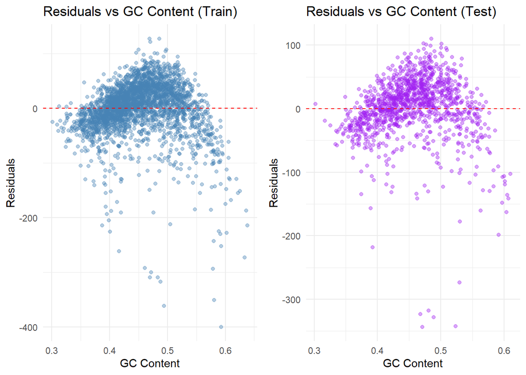

```r
# Plot residuals as a function of GC content for training data
train_gc_plot <- ggplot(train_set_2, aes(x = GC_content, y = residuals)) +
  geom_point(alpha = 0.4, color = "steelblue") +
  geom_hline(yintercept = 0, linetype = "dashed", color = "red") +
  labs(title = "Residuals vs GC Content (Train)",
       x = "GC Content", y = "Residuals") +
  theme_minimal()

# Plot residuals as a function of GC content for test data
test_gc_plot <- ggplot(test_set_2, aes(x = GC_content, y = residuals)) +
  geom_point(alpha = 0.4, color = "purple") +
  geom_hline(yintercept = 0, linetype = "dashed", color = "red") +
  labs(title = "Residuals vs GC Content (Test)",
       x = "GC Content", y = "Residuals") +
  theme_minimal()

# Arrange the plots side by side
grid.arrange(train_gc_plot, test_gc_plot, ncol = 2)
```

### As a Function of Predicted Value:

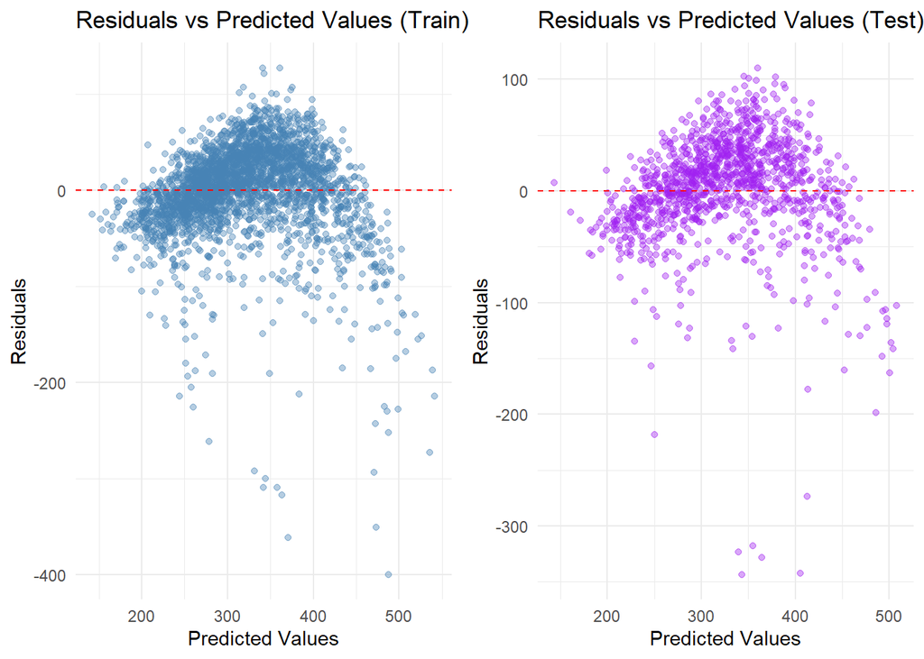

```r
# Plot residuals as a function of predicted values for training data
train_pred_plot <- ggplot(train_set_2, aes(x = predicted, y = residuals)) +
  geom_point(alpha = 0.4, color = "steelblue") +
  geom_hline(yintercept = 0, linetype = "dashed", color = "red") +
  labs(title = "Residuals vs Predicted Values (Train)",
       x = "Predicted Values", y = "Residuals") +
  theme_minimal()

# Plot residuals as a function of predicted values for test data
test_pred_plot <- ggplot(test_set_2, aes(x = predicted, y = residuals)) +
  geom_point(alpha = 0.4, color = "purple") +
  geom_hline(yintercept = 0, linetype = "dashed", color = "red") +
  labs(title = "Residuals vs Predicted Values (Test)",
       x = "Predicted Values", y = "Residuals") +
  theme_minimal()

# Arrange the plots side by side
grid.arrange(train_pred_plot, test_pred_plot, ncol = 2)
```

### As a Function of Chromosome Position:

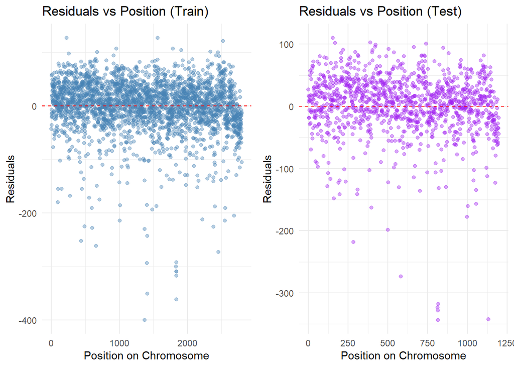

```r
# Plot residuals as a function of position on the chromosome for training data
train_pos_plot <- ggplot(train_set_2, aes(x = position, y = residuals)) +
  geom_point(alpha = 0.4, color = "steelblue") +
  geom_hline(yintercept = 0, linetype = "dashed", color = "red") +
  labs(title = "Residuals vs Position (Train)",
       x = "Position on Chromosome", y = "Residuals") +
  theme_minimal()

# Plot residuals as a function of position on the chromosome for test data
test_pos_plot <- ggplot(test_set_2, aes(x = position, y = residuals)) +
  geom_point(alpha = 0.4, color = "purple") +
  geom_hline(yintercept = 0, linetype = "dashed", color = "red") +
  labs(title = "Residuals vs Position (Test)",
       x = "Position on Chromosome", y = "Residuals") +
  theme_minimal()

# Arrange the plots side by side
grid.arrange(train_pos_plot, test_pos_plot, ncol = 2)
```

**Results Explanations:**

- When we examine the residuals as a function of GC Content vs. residuals as a function of Predicted Value, we get practically the same plot, only on a different scale for the X-axis values. This comes from the fact that, in a simple linear regression, $\hat{y}$ is a linear combination of $x$.the spread of residuals is not equal across all parts of the X-axis, suggesting heteroscedasticity. This implies that the model accuracy changes for cells with different predicted read coverage, leading to more significant errors in different regions.
- On the other hand, when we look at the residuals as a function of Chromosome Position, we can see a uniform spread across the location, suggesting homoscedasticity. This means that the residuals show no systematic bias related to the position on the chromosome, implying that the model errors are not dependent on location.

### Model Improvement Suggestions:

In general, we think there is a lot of ways to improve the model, including: non linear models, a better classification and removal of outliers, or even a applying regularization techniques like Ridge or Lasso regression might help in improving the model performance

## Short summary

In conclusion, we learned that simple linear regression is not the best way to capture the connection between CG content and read coverage. A completely random division of the data is probably the best way to split it in order to examine trends in our case.